# 20190422 tensorflow and keras

```python
import numpy as np
import pandas as pd
import matplotlib as mpl
import matplotlib.pyplot as plt
import seaborn as sns
import missingno as mino
%matplotlib inline
```

```python
# numpy 버전 확인
np.__version__
```

```
'1.16.3'
```

```python
iris = sns.load_dataset('iris')
data, target = pd.DataFrame(iris.iloc[:, :-1]), pd.DataFrame(
    iris.iloc[:, -1], columns=['species'])
iris = pd.concat([data, target], axis=1)
```

# Keras

keras 모듈이 설치되어있지 않다면 아래의 명령어를 입력하여 인스톨한다.

- %pip install keras

```python
import keras
keras.__version__
```

```
'2.2.4'
```

설치가 잘 되었는지 확인해본다.

```python
from keras import backend
backend.print_function
```

```
_Feature((2, 6, 0, 'alpha', 2), (3, 0, 0, 'alpha', 0), 65536)
```

## 단순 순차모델

```python
# from keras.models import Sequential
# model = Sequential()
```

만약 위의 코드를 실행 시 에러가 뜬다면 tensorflow 안에있는 keras 모듈을 사용해본다.

# Tensorflow

- 공식 홈페이지: https://www.tensorflow.org/

tensorflow 모듈이 설치되어있지 않다면 아래의 명령어를 입력하여 패키지를 인스톨한다.

- %pip install tensorflow

```python
import tensorflow as tf
tf.__version__
```

```
'2.0.0-alpha0'
```

패키지 로드가 잘 되는지 확인해본다.

```python
tf.keras
```

```
<module 'tensorflow.python.keras.api._v2.keras' from '/home/user/workspace/.venv/lib/python3.6/site-packages/tensorflow/python/keras/api/_v2/keras/__init__.py'>
```

```python
from sklearn.preprocessing import LabelEncoder
from sklearn.model_selection import train_test_split

encoder = LabelEncoder()
X = data
y = encoder.fit_transform(target)
y = pd.get_dummies(y).values

X_train, X_test, y_train, y_test = train_test_split(X, y)
```

```python
from tensorflow.keras.models import Sequential
from tensorflow.keras.layers import Dense
from tensorflow.keras.optimizers import Adam

model = Sequential()
model.add(Dense(4, input_shape=(4, )))
model.add(Dense(3))

model.compile(Adam(lr=0.04), 'categorical_crossentropy', metrics=['accuracy'])
model.summary()
```

```
Model: "sequential"
_________________________________________________________________
Layer (type)                 Output Shape              Param #
=================================================================
dense (Dense)                (None, 4)                 20
_________________________________________________________________
dense_1 (Dense)              (None, 3)                 15
=================================================================
Total params: 35
Trainable params: 35
Non-trainable params: 0
_________________________________________________________________
```

학습을 시킨 후 그에 대한 예측값을 확인해본다.

```python
model.fit(X_train, y_train, epochs=100)  # 100번 학습
y_pred = model.predict(X_test)
```

학습된 데이터가 예측을 잘했는지 비교해본다.

```python
[np.argmax(y_test[i]) == np.argmax(y_pred[i]) for i in range(y_test.shape[0])]
```

```
[False,
 False,
 False,
 False,
 False,
 False,
 True,
 False,
 True,
 True,
 False,
 False,
 True,
 False,
 False,
 False,
 False,
 False,
 False,
 False,
 False,
 True,
 True,
 False,
 True,
 True,
 True,
 False,
 False,
 True,
 False,
 False,
 False,
 False,
 True,
 False,
 True,
 False]
```

complie 할 때 사용할 수 있는 optimizer 목록과 loss function 목록을 확인해본다.

```python
dir(tf.keras.optimizers)
```

```
['Adadelta',
 'Adagrad',
 'Adam',
 'Adamax',
 'Ftrl',
 'Nadam',
 'Optimizer',
 'RMSprop',
 'SGD',
 '__builtins__',
 '__cached__',
 '__doc__',
 '__file__',
 '__loader__',
 '__name__',
 '__package__',
 '__path__',
 '__spec__',
 'deserialize',
 'get',
 'schedules',
 'serialize']
```

```python
dir(tf.losses)
```

```
['BinaryCrossentropy',
 'CategoricalCrossentropy',
 'CategoricalHinge',
 'CosineSimilarity',
 'Hinge',
 'Huber',
 'KLD',
 'KLDivergence',
 'LogCosh',
 'LogLoss',
 'Loss',
 'MAE',
 'MAPE',
 'MSE',
 'MSLE',
 'MeanAbsoluteError',
 'MeanAbsolutePercentageError',
 'MeanSquaredError',
 'MeanSquaredLogarithmicError',
 'Poisson',
 'Reduction',
 'SparseCategoricalCrossentropy',
 'SquaredHinge',
 '__builtins__',
 '__cached__',
 '__doc__',
 '__file__',
 '__loader__',
 '__name__',
 '__package__',
 '__path__',
 '__spec__',
 'binary_crossentropy',
 'categorical_crossentropy',
 'categorical_hinge',
 'cosine_similarity',
 'deserialize',
 'get',
 'hinge',
 'kld',
 'kullback_leibler_divergence',
 'logcosh',
 'mae',
 'mape',
 'mean_absolute_error',
 'mean_absolute_percentage_error',
 'mean_squared_error',
 'mean_squared_logarithmic_error',
 'mse',
 'msle',
 'poisson',
 'serialize',
 'sparse_categorical_crossentropy',
 'squared_hinge']
```

## Fashion Mnist 데이터 학습시키기

- tensorflow tutorial: https://www.tensorflow.org/tutorials/keras/basic_classification

fashion mnist 데이터는 keras에서 제공하는 의류 이미지 데이터셋이다.

각각의 레이블이 의미하는 것은 다음과 같다.

- [0] 티셔츠/탑
- [1] 바지
- [2] 풀오버(스웨터의 일종)
- [3] 드레스
- [4] 코트
- [5] 샌들
- [6] 셔츠
- [7] 스니커즈
- [8] 가방
- [9] 앵클 부츠

```python
from tensorflow.keras.datasets import fashion_mnist
(X_train, y_train), (X_test, y_test) = fashion_mnist.load_data()
```

불러온 이미지 데이터 하나를 출력해본다.

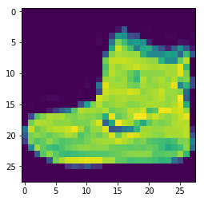

```python
plt.imshow(X_train[0])
```

데이터 크기를 정규화하여 대략적으로 데이터 크기를 동일하게 맞춘다.

```python
X_train = X_train / 255.0
X_test = X_test / 255.0
```

정규화시킨 이미지들을 출력해본다.

```python
# class_names = ['T-shirt/top', 'Trouser', 'Pullover', 'Dress', 'Coat', 'Sandal', 'Shirt', 'Sneaker', 'Bag', 'Ankle boot']
class_names = [
    '티셔츠/탑', '바지', '풀오버(스웨터의 일종)', '드레스', '코트', '샌들', '셔츠', '스니커즈', '가방',
    '앵클 부츠'
]
class_names
```

```
['티셔츠/탑', '바지', '풀오버(스웨터의 일종)', '드레스', '코트', '샌들', '셔츠', '스니커즈', '가방', '앵클 부츠']
```

불러온 이미지 데이터들을 라벨과 함께 출력해본다.

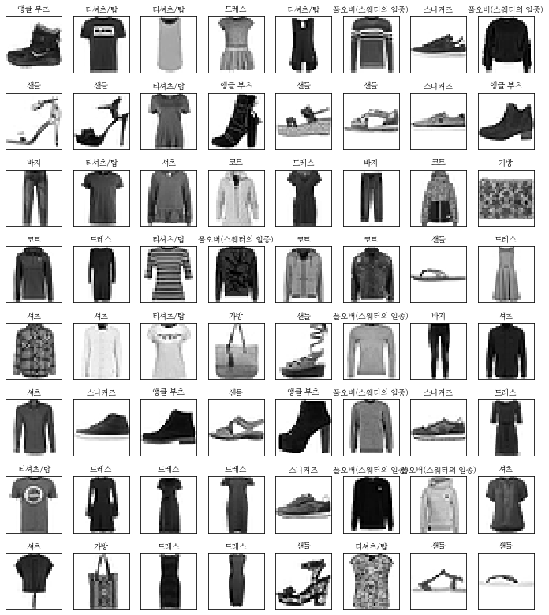

```python
plt.rcParams['font.family'] = 'NanumMyeongjo'

plt.figure(figsize=(12, 14))
for i in range(0, 8 * 8):
    p = plt.subplot(8, 8, i + 1)
    p.get_xaxis().set_visible(False)
    p.get_yaxis().set_visible(False)
    plt.title(class_names[y_train[i]], {'fontsize': 10})
    plt.imshow(X_train[i], cmap=plt.cm.binary)
```

학습을 시키기 위해 모델을 생성한다. 여기서는 단순 순차모델로 학습을 시켜보고자 한다.

```python
from tensorflow.keras.layers import Flatten

model = Sequential([
    Flatten(input_shape=(28, 28)),
    Dense(128, activation=tf.nn.relu),
    Dense(10, activation=tf.nn.softmax)
])
model.compile(optimizer='adam',
              loss='sparse_categorical_crossentropy',
              metrics=['accuracy'])
model.summary()
```

```
Model: "sequential_1"
_________________________________________________________________
Layer (type)                 Output Shape              Param #
=================================================================
flatten (Flatten)            (None, 784)               0
_________________________________________________________________
dense_2 (Dense)              (None, 128)               100480
_________________________________________________________________
dense_3 (Dense)              (None, 10)                1290
=================================================================
Total params: 101,770
Trainable params: 101,770
Non-trainable params: 0
_________________________________________________________________
```

데이터들을 학습시켜본다.

```python
model.fit(X_train, y_train, epochs=10)
```

```
<tensorflow.python.keras.callbacks.History at 0x7fc748059d30>
```

얼마나 잘 예측하는지 직접 확인해본다.

결과는 *정답 -> 실제 예측* 으로 출력한다.

[figure not shown]

```python
y_pred = model.predict_classes(X_test)

plt.figure(figsize=(23, 15))
for i in range(0, 8 * 8):
    p = plt.subplot(8, 8, i + 1)
    p.get_xaxis().set_visible(False)
    p.get_yaxis().set_visible(False)
    plt.title(class_names[y_test[i]] + " -> " + class_names[y_pred[i]],
              {'fontsize': 10})
    plt.imshow(X_test[i], cmap=plt.cm.binary)
```

학습이 잘 되었는지 다음과 같이 성능을 수치화해본다.

결과로 나온 리스트의 1번째 인덱스에 해당하는 값이 정확도이다.

```python
model.evaluate(X_test, y_test, verbose=0)
```

```
[0.34001557549238204, 0.8816]
```

## 모델 저장과 복원

```python
# %pip install -q h5py pyyaml
```

```python
model.save('./fashion_mnist.model')
```

```python
model = Sequential([
    Flatten(input_shape=(28, 28)),
    Dense(128, activation=tf.nn.relu),
    Dense(10, activation=tf.nn.softmax)
])
model.compile(optimizer='adam',
              loss='sparse_categorical_crossentropy',
              metrics=['accuracy'])
```

```python
model.load_weights('./fashion_mnist.model')
model.summary()
```

```
Model: "sequential_2"
_________________________________________________________________
Layer (type)                 Output Shape              Param #
=================================================================
flatten_1 (Flatten)          (None, 784)               0
_________________________________________________________________
dense_4 (Dense)              (None, 128)               100480
_________________________________________________________________
dense_5 (Dense)              (None, 10)                1290
=================================================================
Total params: 101,770
Trainable params: 101,770
Non-trainable params: 0
_________________________________________________________________
```

```python
model.evaluate(X_test, y_test, verbose=0)
```

```
[0.34001557549238204, 0.8816]
```